# rasp: analysis of alternative splicing through splicing ratios

Jinxing Wei, Mikel Esnaola, Pol Cuscó and Juan R. Gonzalez

Department of Mathematics, Autonomous University of Barcelona (UAB)  
Bioinformatics Research Group in Epidemiolgy (BRGE), Barcelona Insitute for Global Health (ISGlobal)

juanr.gonzalez@isglobal.org

2020-06-22

#### Package

rasp 1.5.0

# 1 Getting started

This document gives an overview of the R package `rasp`, which provides statistical procedures to study differential splicing among conditions in the context of annotated genomes. That is, isoform information is summarized using the available annotation (at exon or transcript level) using any of the existing tools. This information can provided in RPKM as for instance [FluxCapacitor](http://big.crg.cat/services/flux_capacitor) does, or using read counts on exons. The statistical methods used in `rasp` are described in Gonzalez-Porta et al. (2012). The method is based on comparing the variability of the relative expression among conditions using the methodology described in Anderson (2006) that can be seen as an ANOVA for the case of having multivariate data (multiple isoforms or exons per gene). The current vesion of the package also allows the user to compare splicing patterns for more than two conditions and adjust for other covariates using non-parametric multivariate linear models whose p-values are computed using an asymptotic result described in Garrido Martı́n and others (2020).

The package can other dependencies can be installed by

```r
devtools::install_github("dgarrimar/mlm")
devtools::install_github("isglobal-brge/rasp")
```

Then, we should start the R session by loading the library as usual:

```r
library(rasp)
```

```r
data(YRI)
dim(YRI)
```

```
[1] 4673   71
```

From an excerpt of YRI, we can see the first two columns containing the gene and transcript Ensembl IDs, respectively, and then the expression values for all samples in the rest of the columns.

```r
YRI[1:6, 1:6]
```

```
            gene_id   transcript_id    NA18486    NA18498  NA18499   NA18501
148 ENSG00000215915 ENST00000378774  32.035839  28.341711 16.51900 37.971313
149 ENSG00000215915 ENST00000378785   0.454634   0.000000  0.00000  0.000000
150 ENSG00000215915 ENST00000435474   0.000000   0.569946  0.00000  0.000000
476 ENSG00000116288 ENST00000338639 123.350471 221.522873 97.17284 83.106064
477 ENSG00000116288 ENST00000460192  23.837547   7.242503 14.23821  8.178253
577 ENSG00000142657 ENST00000487775   0.000000   7.251048 15.00233  8.385659
```

The object also contains information about gender of each sample that will be used as a grouping factor to illustrate comparison among conditions:

```r
genderYRI <- attr(YRI, "gender")
head(genderYRI)
```

```
[1] male   male   female male   female male
Levels: female male
```

```r
table(genderYRI)
```

```
genderYRI
female   male
    40     29
```

We are aware that this is not the proper way of encapsulating omic data since, for instance, Bioconductor has better data infrastructures such as `RangedSummarizedExperiment` that are specifically designed to deal with this type of data. Nontheless, we allow the function pass the data in that format to facilitate the task for those users who are not familiar with Bioconductor or that want to analyze a subset of data obtained from public repositories. [Section Data in `RangedSummarizedExperiment` format] illustrate an example having this type of data.

# 2 Data Visualization

For each gene $n$ alternative splice forms (exons or transcripts) are computed from count data Therfore, for a given gene, and for each individual $j$, the relative expression of each exon, $i=1, \ldots, n$ is computed as: %
$$\begin{equation}
f_{ij} = \frac{x_{ij}}{\sum_{i=1}^{n}x_{ij}}
\end{equation}$$
% where $x_{ij}$ denotes the transcript expression estimates (either as RPKMs or counts). Therefore, we consider as a outcome the vector of splicing proportions for the $j$ individual, $f_{j}=(f_{1j}, \ldots,f_{nj})$. This multivariate nature of the data is the reason why Gonzalez-Porta et al. (2012) proposed to use the methodology described in Anderson (2006) to compare groups.

This type of data is also known as compositional data and can be represented in the simplex using the function `plotTernary()` as illustrate Figure that can be obtained by typing

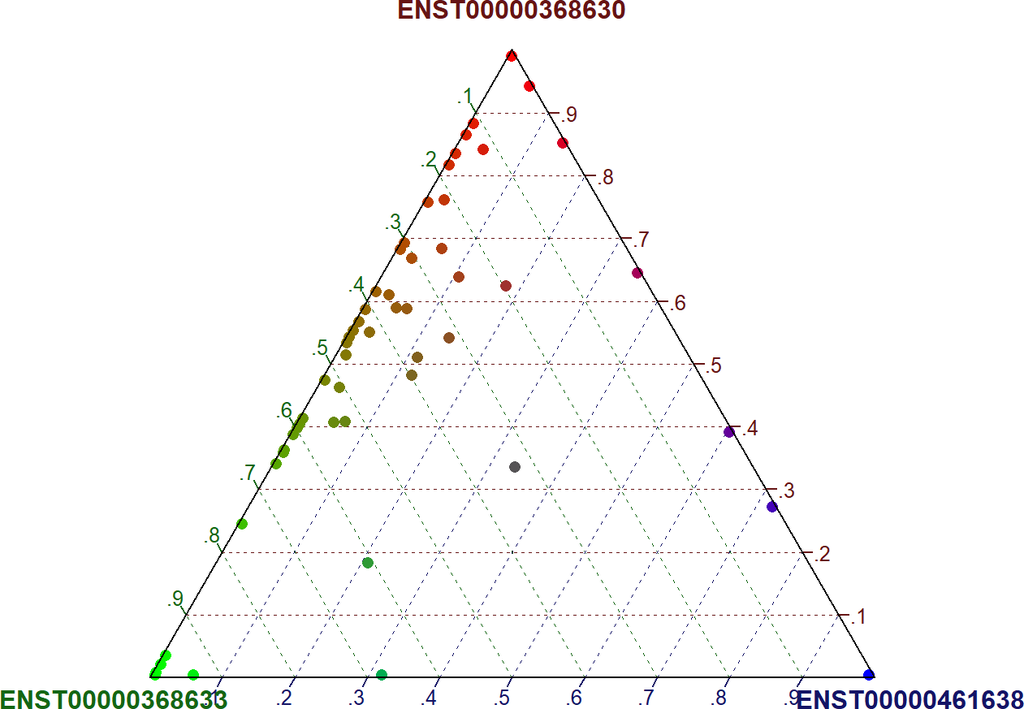

Figure 1: Ternary plot  
Ternary plot corresponding to the splicing ratios of three transcripts (1st, 2nd and 3rd) belonging to gene ENSG00000160741.

```r
plotTernary(YRI, "ENSG00000160741", transcripts=1:3)
```

We can also compare the splicing ratios for a group of individuals using the `group` argument. For instance, next figure illustrat the splicing of males and females for the gene JRK (ENSG00000234616) and we can observe a very different pattern having females higher splicing ratios of exon ENST00000413868.

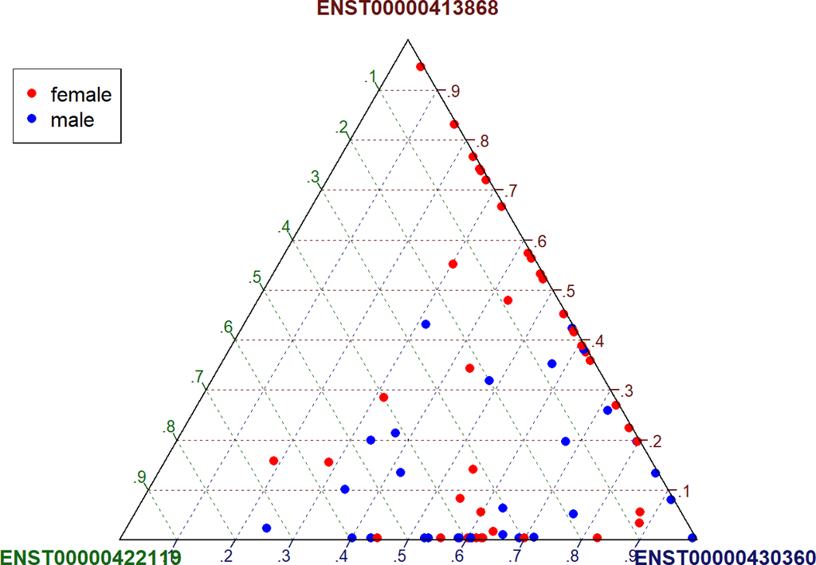

```r
plotTernary(YRI, "ENSG00000234616", group = genderYRI, transcripts=1:3)
```

Notice that the argument `transcript` indicates the three transcripts to be represented in the Ternary plot. An obvious limitation of the Ternary Plot is that it can oly plot data for three different transcripts. In order to plot the splicing ratios for any number of transcripts one can use the function `plotAllIso()`. The result is a plot showing the splicing ratios for all selected transcripts and individuals separated by gener.

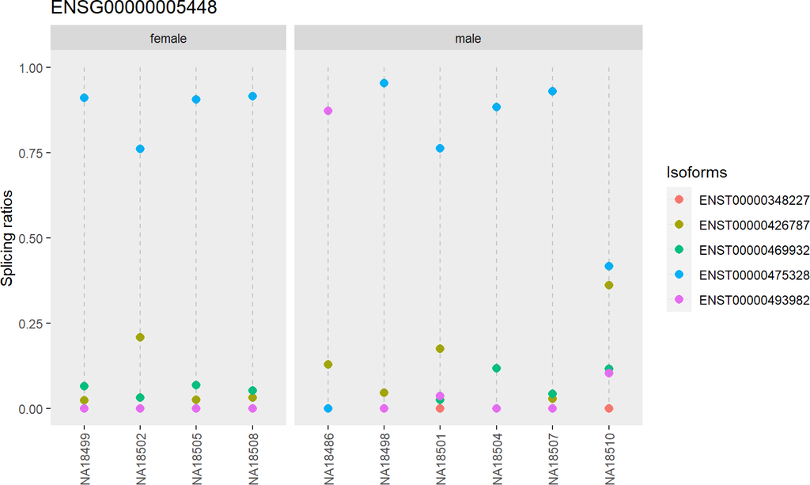

Figure 3: Isforoms plot  
Plot showing splicing ratios of all transcripts in gene ENSG00000005448.

```r
plotAllIso("ENSG00000005448", data = YRI, group = genderYRI,
                      inds = 1:10)
```

# 3 Data analysis

The splicing ratio for a single gene can be analyzed using the `rasp()` function. For instance, let us investigate whether the splicing ratios of the gene ENSG00000160741 containing 3 different transcripts are different between males and females (Figure ).

We first need to select the counts corresponding to the gene of interest

```r
counts.gene <- YRI[YRI$gene_id=="ENSG00000160741", ]
```

And then the p-value is computed by

```r
pval <- rasp(x=counts.gene, group=genderYRI,
            geneidCol = 1, expressionCols = 3:ncol(counts.gene))
pval
```

```
                n.exons       pvalue
ENSG00000160741       3 0.0006169611
attr(,"class")
[1] "rasp"   "matrix"
```

Notice that three arguments must be specified. First, which vector is having the groupin variable (`group`). Then, which column is having the gene ids (`gendidCol`) and then the columns having the counts or expression (`expressionCols`) in the `x` agument.

More than one gene can also be analyzed using `rasp()` function. It is performed by using multiple processors when available. Let us analyze, for instance, the first 5 genes can be studied by

```r
ngenes <- 5
sel.genes <-  names(table(YRI$gene_id))[1:ngenes]
YRI.subset <- subset(YRI, gene_id%in%sel.genes)
res <- rasp(x=YRI.subset, group=genderYRI, mc.cores = 3,
            geneidCol = 1, expressionCols = 3:ncol(YRI))
```

Notice again that having data in that simple format requires several arguments to be passed through the function as previously illustrated. The argument `mc.cores` allows the user to pre-define the number of cores used. If missing, it considers `parallel::detectCores() - 1`. We can see the p-values of each gene by printing the results

```r
res
```

```
                n.exons    pvalue   padjust
ENSG00000004700       3 0.4508945 0.5636181
ENSG00000004897       3 0.1372127 0.5636181
ENSG00000005339       3 0.4339895 0.5636181
ENSG00000005448       5 0.9463993 0.9463993
ENSG00000005700       2 0.3148086 0.5636181
attr(,"class")
[1] "rasp"   "matrix"
```

# 4 Analysis with `RangedSummarizedExperiment` objects

As previously mentioned the `RangedSummarizedExperiment` is designed to properely manage exon/transcript count data. In order to illustrate how to perform differential splicing analyses using `rasp` we have added into the package an object of this class which contains exon counts measured in adipose tissue from GTEx samples. The object has been donwloaded from [recount](https://jhubiostatistics.shinyapps.io/recount/) and, for illustrating purposes, we have selected the information corresponding to the chromosome 16 and have added a covariable to the metadata called `inv16p11.2` which contains the inversion genotypes obtained as described in Ruiz-Arenas et al. (2019).

```r
data(adipose)
adipose.chr16
```

```
class: RangedSummarizedExperiment
dim: 30359 419
metadata(0):
assays(1): counts
rownames(30359): ENSG00000003249.13 ENSG00000003249.13 ... ENSG00000283689.1
  ENSG00000283689.1
rowData names(0):
colnames(419): SRR1386689 SRR1400202 ... SRR1387013 SRR1454909
colData names(3): id run inv16p11.2
```

The total number of genes are

```r
length(unique(rownames(adipose.chr16)))
```

```
[1] 2511
```

One of the advantadges of using `RangedSummarizedObjects` is that we can easily subset a genomic region and then perfrom downstream analyses. Let us assume that we are interested in studing whether the inversion genotypes are associated with the alternative splicing in the inversion region (chr16:28,42Mb-28,79Mb). The region of interest can be easily subset by

```r
library(GenomicRanges)
library(IRanges)
roi <- GRanges("chr16:25e6-30e6")
adipose <- subsetByOverlaps(adipose.chr16, roi)
adipose
```

```
class: RangedSummarizedExperiment
dim: 2144 419
metadata(0):
assays(1): counts
rownames(2144): ENSG00000013364.18 ENSG00000013364.18 ... ENSG00000283662.1
  ENSG00000283662.1
rowData names(0):
colnames(419): SRR1386689 SRR1400202 ... SRR1387013 SRR1454909
colData names(3): id run inv16p11.2
```

Now the number of genes contained in the object are:

```r
length(unique(rownames(adipose)))
```

```
[1] 171
```

The analysis is the performed by

```r
pvals <- rasp( formula = ~ inv16p11.2, x = adipose)
```

These are the pvalues

```r
head(pvals)
```

```
                   n.exons     pvalue   padjust
ENSG00000013364.18      58 0.37595027 0.8151725
ENSG00000047578.12      47 0.62957446 0.9321674
ENSG00000077235.17      71 0.88974254 0.9321674
ENSG00000077238.13      49 0.02728889 0.2261080
ENSG00000079616.12      42 0.47493731 0.8785826
ENSG00000103375.10       8 0.82683257 0.9321674
```

Notice that here the grouping variable is indicated in the formula. This allows to create adjusted analysis by other covariates that should be available in the metadata (e.g. `colData()`)

The top genes can be obtained by

```r
topGenes(pvals)
```

```
Showing top 6 genes ranked by Corrected p-value
Maximum adjusted P-value of 1
                   n.exons       pvalue      padjust
ENSG00000197165.10      19 1.000000e-14 1.160000e-12
ENSG00000233232.6        9 8.126833e-14 4.713563e-12
ENSG00000259982.1        2 1.859922e-08 7.191697e-07
ENSG00000251417.2        2 3.237936e-04 9.390013e-03
ENSG00000196502.11      35 1.061481e-03 2.139274e-02
ENSG00000278725.1        3 1.228582e-03 2.139274e-02
```

We observe that the gene ENSG00000197165 (SULT1A2) is hihgly differentially spliced. This figure shows the splicing ratios of each exon given the inversion genotypes

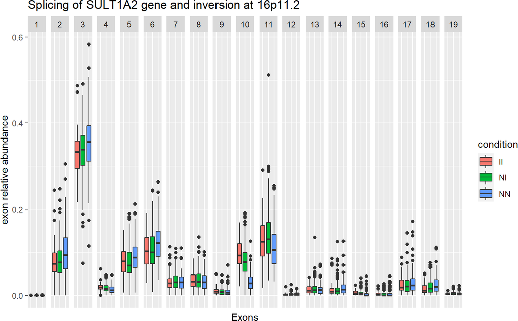

Figure 4: Splicing ratios for adipose tissue (GTEx) and inversion 16p11.2  
Plot shows splicing ratios of each inversion genotype for all exons in gene SULT1A2 (ENSG00000197165).

```r
plotGene(adipose, gene="ENSG00000197165.10", condition="inv16p11.2",
         title="Splicing of SULT1A2 gene and inversion at 16p11.2")
```

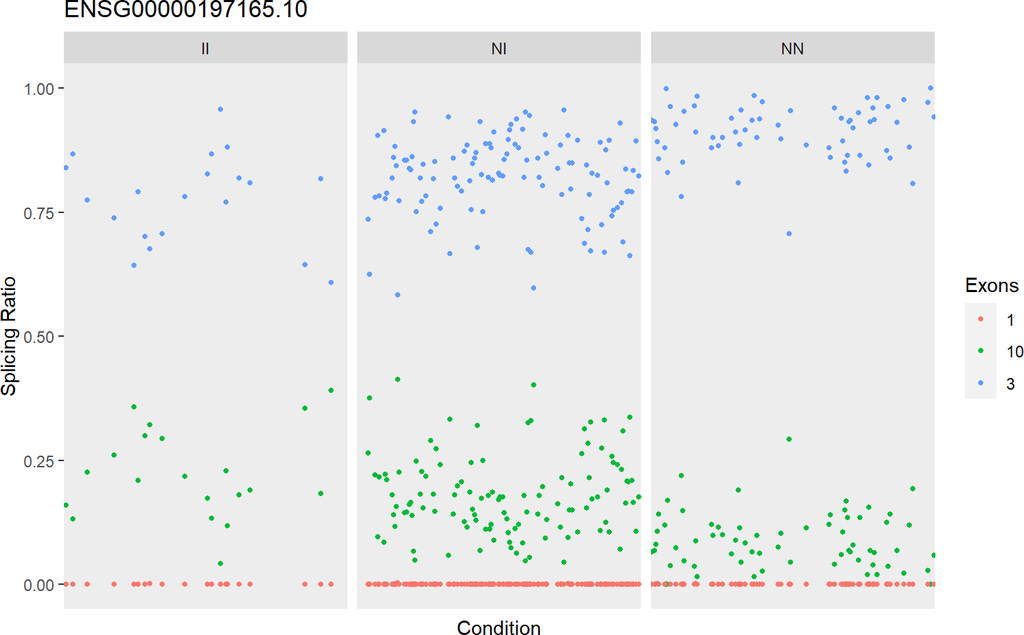

```r
plotSplicingRatios("ENSG00000197165.10", data = adipose,
              condition = "inv16p11.2", ind=1:200, exons=c(1,3,10))
```

# 5 References

Anderson, M. J. 2006. “Distance-based tests for homogeneity of multivariate dispersion.” *Biometrics* 62: 245–53.

Garrido Martı́n, Diego, and others. 2020. “A Multivariate Approach to Study the Genetic Determinants of Phenotypic Traits.” PhD thesis, Universitat Pompeu Fabra.

Gonzalez-Porta, M, M Calvo, M Sammeth, and Guigo R. 2012. “Estimation of Alternative Splicing Variability in Human Populations.” *Genome Research* 22 (3): 528–38.

González, Juan R. 2019. “Polymorphic Inversions Underlie the Shared Genetic Susceptibility to Prevalent Common Diseases.” *bioRxiv*, 859280.

Marco-Sola, Santiago, Michael Sammeth, Roderic Guigó, and Paolo Ribeca. 2012. “The Gem Mapper: Fast, Accurate and Versatile Alignment by Filtration.” *Nat Methods* 9 (12): 1185–8. https://doi.org/10.1038/nmeth.2221.

Pickrell, J. K., J. C. Marioni, A. A. Pai, J. F. Degner, B. E. Engelhardt, E. Nkadori, J. B. Veyrieras, M. Stephens, Y. Gilad, and J. K. Pritchard. 2010. “Understanding mechanisms underlying human gene expression variation with RNA sequencing.” *Nature* 464: 768–72.

Ruiz-Arenas, Carlos, Alejandro Caceres, Marcos Lopez-Sanchez, Ignacio Tolosana, Luis Perez-Jurado, and Juan R Gonzalez. 2019. “ScoreInvHap: Inversion Genotyping for Genome-Wide Association Studies.” *PLoS Genetics* 15 (7).